# MEDBS datacall Report

Compiled on 23/05/2022, 09:09

# 1 Catch table

## 1.1 Presence of duplicated records

Data included in the catch table were checked for the presence of duplicated records. The result of the check is here reported:

- No replicated records in Catch data

*Attention*: eventual duplicated records will be removed from catch data for the following analysis

## 1.2 Coverage of catch data

### 1.2.1 GSA 18

#### 1.2.1.1 HKE

*Coverage of landing data for HKE in GSA 18*

| COUNTRY | YEAR | AREA | SPECIES | LANDINGS |
| --- | --- | --- | --- | --- |
| ITA | 2002 | GSA 18 | HKE | 2309.142 |
| ITA | 2003 | GSA 18 | HKE | 4450.769 |
| ITA | 2004 | GSA 18 | HKE | 3204.111 |
| ITA | 2005 | GSA 18 | HKE | 3784.651 |
| ITA | 2006 | GSA 18 | HKE | 5506.318 |
| ITA | 2007 | GSA 18 | HKE | 4154.556 |
| ITA | 2008 | GSA 18 | HKE | 4247.904 |
| ITA | 2009 | GSA 18 | HKE | 4105.819 |
| ITA | 2010 | GSA 18 | HKE | 4020.612 |
| ITA | 2011 | GSA 18 | HKE | 3849.697 |
| ITA | 2012 | GSA 18 | HKE | 3105.702 |
| ITA | 2013 | GSA 18 | HKE | 2566.947 |
| ITA | 2014 | GSA 18 | HKE | 1863.625 |
| ITA | 2015 | GSA 18 | HKE | 2040.697 |
| ITA | 2016 | GSA 18 | HKE | 2194.563 |
| ITA | 2017 | GSA 18 | HKE | 2230.520 |
| ITA | 2018 | GSA 18 | HKE | 2000.253 |
| ITA | 2019 | GSA 18 | HKE | 1722.238 |
| ITA | 2020 | GSA 18 | HKE | 1353.534 |

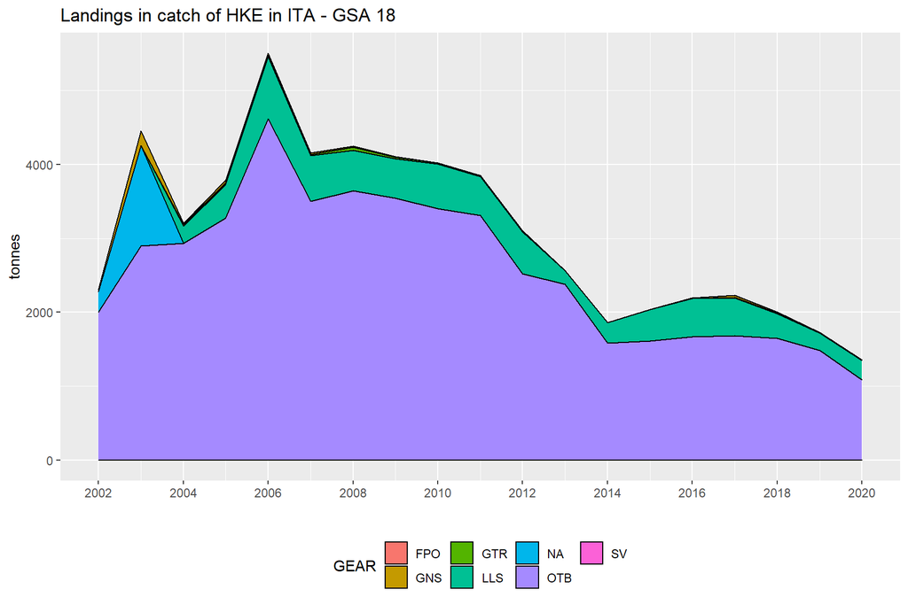

*Coverage of discard data for HKE in GSA 18*

| COUNTRY | YEAR | AREA | SPECIES | DISCARDS |
| --- | --- | --- | --- | --- |
| ITA | 2009 | GSA 18 | HKE | 151.60242 |
| ITA | 2010 | GSA 18 | HKE | 77.86157 |
| ITA | 2011 | GSA 18 | HKE | 99.69113 |
| ITA | 2012 | GSA 18 | HKE | 177.32864 |
| ITA | 2013 | GSA 18 | HKE | 15.36081 |
| ITA | 2014 | GSA 18 | HKE | 46.79378 |
| ITA | 2015 | GSA 18 | HKE | 86.24911 |
| ITA | 2016 | GSA 18 | HKE | 107.10148 |
| ITA | 2017 | GSA 18 | HKE | 31.43257 |
| ITA | 2018 | GSA 18 | HKE | 55.88577 |
| ITA | 2019 | GSA 18 | HKE | 102.13291 |
| ITA | 2020 | GSA 18 | HKE | 18.97022 |

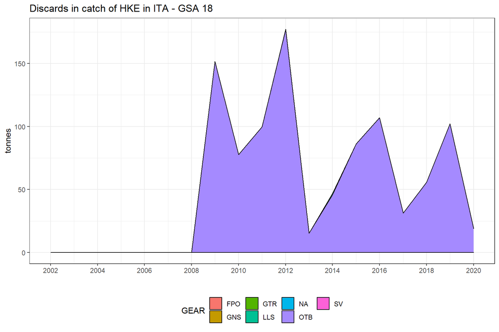

### 1.2.2 GSA 19

#### 1.2.2.1 HKE

*Coverage of landing data for HKE in GSA 19*

| COUNTRY | YEAR | AREA | SPECIES | LANDINGS |
| --- | --- | --- | --- | --- |
| ITA | 2002 | GSA 19 | HKE | 1356.8194 |
| ITA | 2003 | GSA 19 | HKE | 1513.8160 |
| ITA | 2004 | GSA 19 | HKE | 1298.7318 |
| ITA | 2005 | GSA 19 | HKE | 1271.1942 |
| ITA | 2006 | GSA 19 | HKE | 1629.1298 |
| ITA | 2007 | GSA 19 | HKE | 882.3411 |
| ITA | 2008 | GSA 19 | HKE | 932.1399 |
| ITA | 2009 | GSA 19 | HKE | 998.6430 |
| ITA | 2010 | GSA 19 | HKE | 838.7930 |
| ITA | 2011 | GSA 19 | HKE | 810.2298 |
| ITA | 2012 | GSA 19 | HKE | 674.8485 |
| ITA | 2013 | GSA 19 | HKE | 760.3392 |
| ITA | 2014 | GSA 19 | HKE | 739.9736 |
| ITA | 2015 | GSA 19 | HKE | 806.5847 |
| ITA | 2016 | GSA 19 | HKE | 706.8578 |
| ITA | 2017 | GSA 19 | HKE | 713.5316 |
| ITA | 2018 | GSA 19 | HKE | 659.6122 |
| ITA | 2019 | GSA 19 | HKE | 669.1320 |
| ITA | 2020 | GSA 19 | HKE | 614.1151 |

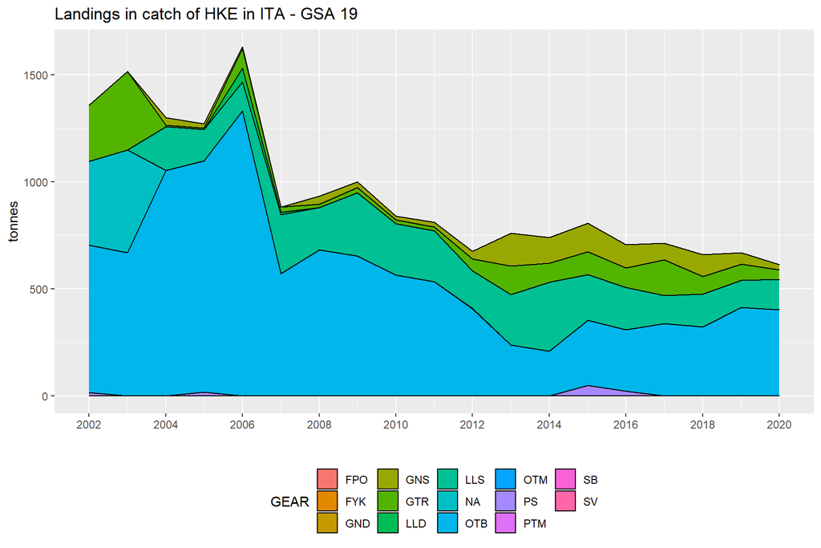

*Coverage of discard data for HKE in GSA 19*

| COUNTRY | YEAR | AREA | SPECIES | DISCARDS |
| --- | --- | --- | --- | --- |
| ITA | 2006 | GSA 19 | HKE | 34.17037 |
| ITA | 2009 | GSA 19 | HKE | 53.12721 |
| ITA | 2010 | GSA 19 | HKE | 10.95757 |
| ITA | 2011 | GSA 19 | HKE | 8.56390 |
| ITA | 2012 | GSA 19 | HKE | 11.47827 |
| ITA | 2013 | GSA 19 | HKE | 11.45418 |
| ITA | 2014 | GSA 19 | HKE | 3.85250 |
| ITA | 2015 | GSA 19 | HKE | 5.36492 |
| ITA | 2016 | GSA 19 | HKE | 17.82643 |
| ITA | 2017 | GSA 19 | HKE | 5.38637 |
| ITA | 2018 | GSA 19 | HKE | 12.32796 |
| ITA | 2019 | GSA 19 | HKE | 39.79820 |
| ITA | 2020 | GSA 19 | HKE | 0.41658 |

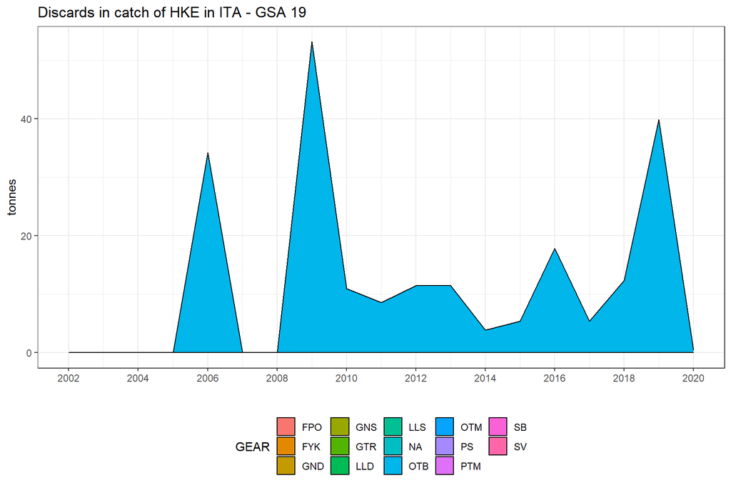

## 1.3 Check of Sum of Products (SOP)

The result of the percentage difference of SOP and both landing and discard volumes are reported in the following table in case the value is greater then 5% (selected threshold value):

### 1.3.1 GSA 18

#### 1.3.1.1 HKE

*Critical values of SOP for HKE in GSA 18*

|  | YEAR | QUARTER | VESSEL_LENGTH | GEAR | MESH_SIZE_RANGE | FISHERY | check_LANDING | check_DISCARD |
| --- | --- | --- | --- | --- | --- | --- | --- | --- |
| 49673 | 2009 | -1 | NA | OTB | 40D50 | MDD |  | 7.42 |
| 49740 | 2010 | -1 | NA | OTB | 40D50 | DEF |  | 9.21 |
| 49770 | 2010 | -1 | NA | OTB | 40D50 | MDD |  | 7.09 |
| 50026 | 2013 | -1 | NA | OTB | 50D100 | MDD |  | 7.44 |
| 50419 | 2016 | 2 | NA | OTB | 50D100 | DEF |  | 6.97 |
| 50437 | 2016 | 3 | NA | OTB | 50D100 | DEF |  | 7.29 |
| 50508 | 2016 | 2 | NA | OTB | 50D100 | MDD |  | 8.82 |
| 50797 | 2017 | 2 | NA | OTB | 50D100 | DEF |  | 6.32 |
| 50876 | 2017 | 2 | NA | OTB | 50D100 | MDD |  | 8.46 |
| 51229 | 2018 | 1 | NA | OTB | 50D100 | DEF |  | 9.17 |
| 51280 | 2018 | 3 | NA | OTB | 50D100 | DEF |  | 6.92 |
| 51304 | 2018 | 4 | NA | OTB | 50D100 | DEF |  | 7.75 |
| 64937 | 2018 | 1 | NA | OTB | 50D100 | MDD |  | 7.44 |
| 65353 | 2019 | 1 | NA | OTB | 50D100 | DEF |  | 8.41 |
| 65376 | 2019 | 2 | NA | OTB | 50D100 | DEF |  | 5.08 |
| 65791 | 2020 | 2 | NA | OTB | 50D100 | DEF |  | 5.8 |
| 65793 | 2020 | 4 | NA | OTB | 50D100 | DEF |  | 6.68 |
| 65799 | 2020 | 2 | NA | OTB | 50D100 | MDD |  | 5.35 |
| 65800 | 2020 | 3 | NA | OTB | 50D100 | MDD |  | 5.29 |
| 65801 | 2020 | 4 | NA | OTB | 50D100 | MDD |  | 6.67 |

### 1.3.2 GSA 19

#### 1.3.2.1 HKE

*Critical values of SOP for HKE in GSA 19*

|  | YEAR | QUARTER | VESSEL_LENGTH | GEAR | MESH_SIZE_RANGE | FISHERY | check_LANDING | check_DISCARD |
| --- | --- | --- | --- | --- | --- | --- | --- | --- |
| 66600 | 2006 | -1 | NA | GNS | 16D20 | DEF | 5.13 |  |
| 66602 | 2006 | -1 | NA | OTB | 40D50 | NA |  | 9.37 |
| 66853 | 2008 | -1 | NA | GTR | 16D20 | DEF | 5.19 |  |
| 67273 | 2011 | -1 | NA | OTB | 50D100 | DEF |  | 5.11 |
| 67736 | 2014 | -1 | NA | OTB | 50D100 | NA |  | 5.64 |
| 72985 | 2016 | 2 | NA | OTB | 50D100 | NA |  | 7.09 |
| 72986 | 2016 | 3 | NA | OTB | 50D100 | NA |  | 8.62 |
| 72987 | 2016 | 4 | NA | OTB | 50D100 | NA |  | 7.05 |
| 78347 | 2017 | -1 | NA | OTB | 50D100 | MDD |  | 7.42 |
| 80999 | 2018 | 1 | NA | OTB | 50D100 | DEF |  | 9.85 |
| 81001 | 2018 | 3 | NA | OTB | 50D100 | DEF |  | 6.5 |
| 81002 | 2018 | 4 | NA | OTB | 50D100 | DEF |  | 8.97 |
| 81005 | 2018 | 2 | NA | OTB | 50D100 | MDD |  | 8.05 |
| 82566 | 2020 | -1 | NA | OTB | 50D100 | DEF |  | 9.33 |

# 2 Landing table

## 2.1 Presence of duplicated records

Data included in the landing table were checked for the presence of duplicated records. The result of the check is here reported:

- No replicated records in Landings data

## 2.2 Coverage of landings data

### 2.2.1 GSA 18

#### 2.2.1.1 HKE

*Coverage of landing data for HKE in GSA 18*

| COUNTRY | YEAR | AREA | SPECIES | LANDINGS |
| --- | --- | --- | --- | --- |
| ITA | 2002 | GSA 18 | HKE | 2309.142 |
| ITA | 2003 | GSA 18 | HKE | 4450.769 |
| ITA | 2004 | GSA 18 | HKE | 3204.111 |
| ITA | 2005 | GSA 18 | HKE | 3784.651 |
| ITA | 2006 | GSA 18 | HKE | 5506.318 |
| ITA | 2007 | GSA 18 | HKE | 4154.556 |
| ITA | 2008 | GSA 18 | HKE | 4247.904 |
| ITA | 2009 | GSA 18 | HKE | 4105.819 |
| ITA | 2010 | GSA 18 | HKE | 4020.612 |
| ITA | 2011 | GSA 18 | HKE | 3849.697 |
| ITA | 2012 | GSA 18 | HKE | 3105.702 |
| ITA | 2013 | GSA 18 | HKE | 2566.947 |
| ITA | 2014 | GSA 18 | HKE | 1863.625 |
| ITA | 2015 | GSA 18 | HKE | 2040.697 |
| ITA | 2016 | GSA 18 | HKE | 2194.563 |
| ITA | 2017 | GSA 18 | HKE | 2230.520 |
| ITA | 2018 | GSA 18 | HKE | 2000.253 |
| ITA | 2019 | GSA 18 | HKE | 0.000 |
| ITA | 2020 | GSA 18 | HKE | 1353.534 |

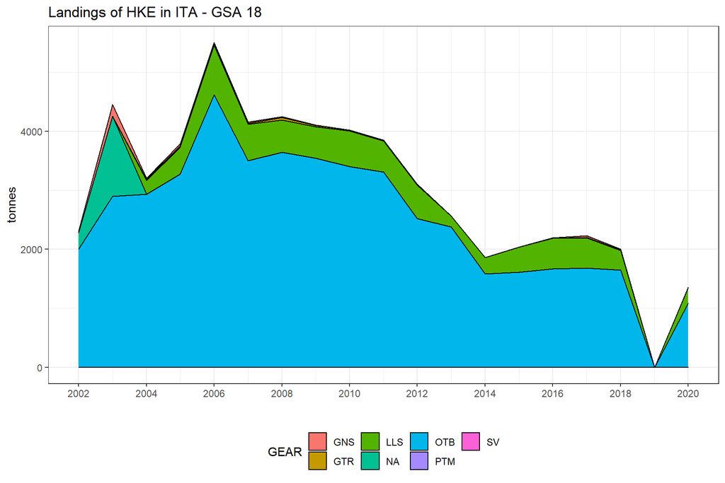

### 2.2.2 GSA 19

#### 2.2.2.1 HKE

*Coverage of landing data for HKE in GSA 19*

| COUNTRY | YEAR | AREA | SPECIES | LANDINGS |
| --- | --- | --- | --- | --- |
| ITA | 2002 | GSA 19 | HKE | 1356.8194 |
| ITA | 2003 | GSA 19 | HKE | 1513.8160 |
| ITA | 2004 | GSA 19 | HKE | 1298.7318 |
| ITA | 2005 | GSA 19 | HKE | 1271.1942 |
| ITA | 2006 | GSA 19 | HKE | 1629.1298 |
| ITA | 2007 | GSA 19 | HKE | 882.3411 |
| ITA | 2008 | GSA 19 | HKE | 932.1399 |
| ITA | 2009 | GSA 19 | HKE | 998.6430 |
| ITA | 2010 | GSA 19 | HKE | 838.7930 |
| ITA | 2011 | GSA 19 | HKE | 810.2298 |
| ITA | 2012 | GSA 19 | HKE | 674.8485 |
| ITA | 2013 | GSA 19 | HKE | 760.3392 |
| ITA | 2014 | GSA 19 | HKE | 739.9736 |
| ITA | 2015 | GSA 19 | HKE | 806.5847 |
| ITA | 2016 | GSA 19 | HKE | 706.8578 |
| ITA | 2017 | GSA 19 | HKE | 713.5316 |
| ITA | 2018 | GSA 19 | HKE | 659.6122 |
| ITA | 2019 | GSA 19 | HKE | 669.1320 |
| ITA | 2020 | GSA 19 | HKE | 614.1151 |

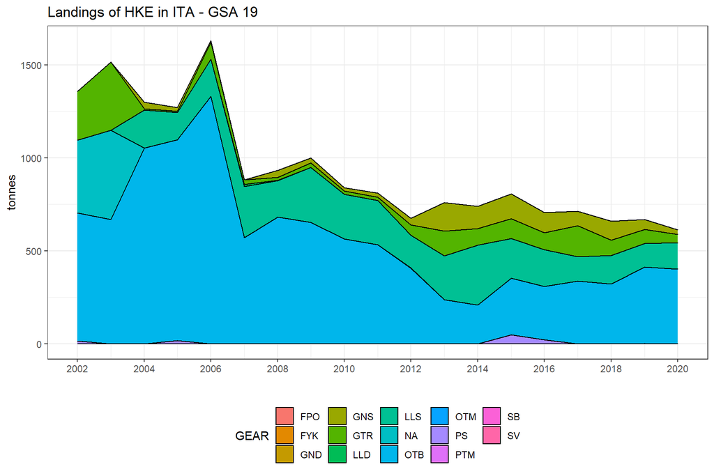

## 2.3 Checks on landing volumes

### 2.3.1 Comparison of landing volumes aggregated by quarter and fishery accounting for vessel length

#### 2.3.1.1 GSA 18

##### 2.3.1.1.1 HKE

- No landing volumes aggregated by quarter and fishery are reported with and without vessel codes at the same time for the selected combination: HKE - ITA - GSA 18

#### 2.3.1.2 GSA 19

##### 2.3.1.2.1 HKE

- No landing volumes aggregated by quarter and fishery are reported with and without vessel codes at the same time for the selected combination: HKE - ITA - GSA 19

### 2.3.2 Comparison of landing volumes aggregated by fishery accounting for time frame

### 2.3.3 GSA 18

#### 2.3.3.1 HKE

- No landing volumes aggregated by fishery are reported for both the time frames (quarter/year) for the selected combination: HKE - ITA - GSA 18

### 2.3.4 GSA 19

#### 2.3.4.1 HKE

- No landing volumes aggregated by fishery are reported for both the time frames (quarter/year) for the selected combination: HKE - ITA - GSA 19

## 2.4 Kolmogorov-Smirnov test

The Kolmogorov-Smirnov test provides cumulative length distribution plots by fishery and year. The test is performed on couples of years to assess if their distributions belong to the same population.

### 2.4.1 GSA 18

#### 2.4.1.1 HKE

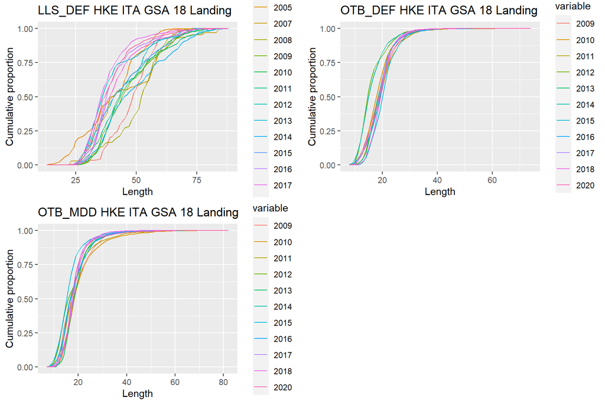

*Summary table of Kolmogorov-Smirnov test for HKE in GSA 18*

| Group | NTot_yr1 | NTot_yr2 | Dmax | Dcalc | H0_p0.05 | Comment | ID |
| --- | --- | --- | --- | --- | --- | --- | --- |
| 2009 vs 2010 | 502.471 | 581.5160 | 0.054 | 0.1053712 | accepted | belong to same population | LLS_DEF |
| 2009 vs 2011 | 502.471 | 499.9060 | 0.067 | 0.1092854 | accepted | belong to same population | LLS_DEF |
| 2009 vs 2014 | 502.471 | 220.1510 | 0.085 | 0.1398253 | accepted | belong to same population | LLS_DEF |
| 2010 vs 2011 | 581.516 | 499.9060 | 0.081 | 0.1055161 | accepted | belong to same population | LLS_DEF |
| 2010 vs 2014 | 581.516 | 220.1510 | 0.103 | 0.1368995 | accepted | belong to same population | LLS_DEF |
| 2011 vs 2014 | 499.906 | 220.1510 | 0.119 | 0.1399346 | accepted | belong to same population | LLS_DEF |
| 2011 vs 2015 | 499.906 | 454.9380 | 0.106 | 0.1120965 | accepted | belong to same population | LLS_DEF |
| 2012 vs 2015 | 650.745 | 454.9380 | 0.082 | 0.1057255 | accepted | belong to same population | LLS_DEF |
| 2013 vs 2020 | 262.949 | 430.0004 | 0.085 | 0.1354337 | accepted | belong to same population | LLS_DEF |
| 2016 vs 2018 | 793.784 | 436.0620 | 0.081 | 0.1031208 | accepted | belong to same population | LLS_DEF |
| 2017 vs 2020 | 928.317 | 430.0004 | 0.100 | 0.1009170 | accepted | belong to same population | LLS_DEF |
| 2009 vs 2016 | 5981.381 | 469.3880 | 0.081 | 0.0829249 | accepted | belong to same population | OTB_MDD |
| 2011 vs 2014 | 4043.432 | 710.4730 | 0.057 | 0.0703757 | accepted | belong to same population | OTB_MDD |
| 2011 vs 2016 | 4043.432 | 469.3880 | 0.045 | 0.0843585 | accepted | belong to same population | OTB_MDD |
| 2014 vs 2016 | 710.473 | 469.3880 | 0.064 | 0.1029015 | accepted | belong to same population | OTB_MDD |
| 2017 vs 2018 | 2674.756 | 1670.9800 | 0.033 | 0.0539449 | accepted | belong to same population | OTB_MDD |
| 2017 vs 2020 | 2674.756 | 787.8286 | 0.056 | 0.0701275 | accepted | belong to same population | OTB_MDD |

### 2.4.2 GSA 19

#### 2.4.2.1 HKE

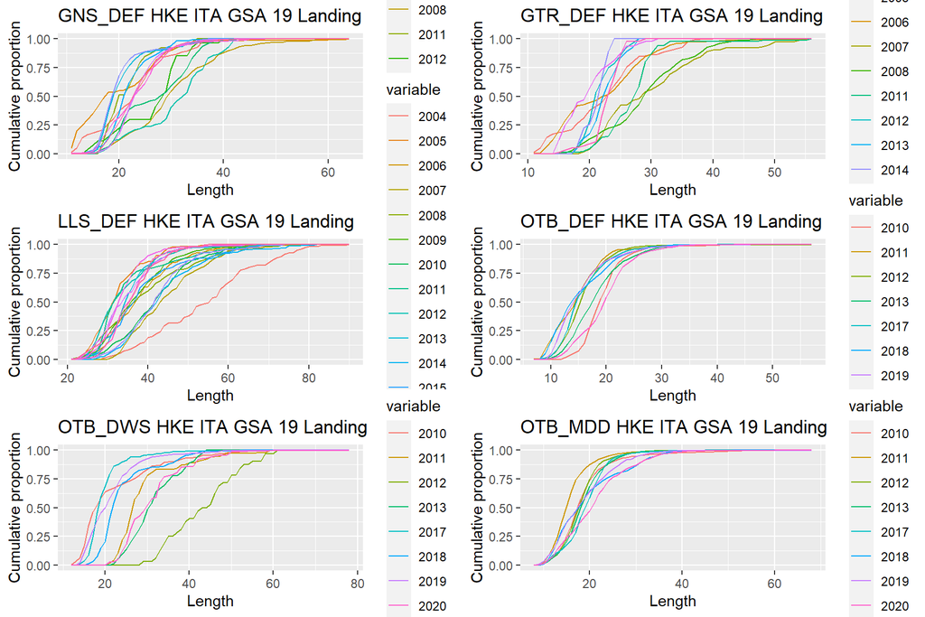

*Summary table of Kolmogorov-Smirnov test for HKE in GSA 19*

| Group | NTot_yr1 | NTot_yr2 | Dmax | Dcalc | H0_p0.05 | Comment | ID |
| --- | --- | --- | --- | --- | --- | --- | --- |
| 2005 vs 2019 | 165.15483 | 452.6400 | 0.157 | 0.1572701 | accepted | belong to same population | GNS_DEF |
| 2015 vs 2017 | 1596.63300 | 994.8690 | 0.065 | 0.0698773 | accepted | belong to same population | GNS_DEF |
| 2018 vs 2020 | 781.08900 | 225.3718 | 0.106 | 0.1308111 | accepted | belong to same population | GNS_DEF |
| 2019 vs 2020 | 452.64000 | 225.3718 | 0.079 | 0.1410388 | accepted | belong to same population | GNS_DEF |
| 2005 vs 2006 | 71.51598 | 761.5710 | 0.154 | 0.2139610 | accepted | belong to same population | GTR_DEF |
| 2007 vs 2008 | 87.78800 | 71.5150 | 0.165 | 0.2755763 | accepted | belong to same population | GTR_DEF |
| 2005 vs 2012 | 479.11000 | 502.4665 | 0.099 | 0.1104681 | accepted | belong to same population | LLS_DEF |
| 2006 vs 2008 | 360.55461 | 296.9340 | 0.113 | 0.1355735 | accepted | belong to same population | LLS_DEF |
| 2006 vs 2009 | 360.55461 | 599.2620 | 0.059 | 0.1153045 | accepted | belong to same population | LLS_DEF |
| 2006 vs 2015 | 360.55461 | 347.0700 | 0.067 | 0.1300929 | accepted | belong to same population | LLS_DEF |
| 2007 vs 2010 | 317.19600 | 342.6070 | 0.123 | 0.1348004 | accepted | belong to same population | LLS_DEF |
| 2007 vs 2014 | 317.19600 | 393.0860 | 0.105 | 0.1305731 | accepted | belong to same population | LLS_DEF |
| 2008 vs 2015 | 296.93400 | 347.0700 | 0.090 | 0.1367577 | accepted | belong to same population | LLS_DEF |
| 2009 vs 2015 | 599.26200 | 347.0700 | 0.077 | 0.1166947 | accepted | belong to same population | LLS_DEF |
| 2009 vs 2020 | 599.26200 | 348.1637 | 0.113 | 0.1165785 | accepted | belong to same population | LLS_DEF |
| 2010 vs 2014 | 342.60700 | 393.0860 | 0.067 | 0.1278652 | accepted | belong to same population | LLS_DEF |
| 2010 vs 2016 | 342.60700 | 284.2190 | 0.055 | 0.1388017 | accepted | belong to same population | LLS_DEF |
| 2013 vs 2019 | 592.90200 | 314.5620 | 0.078 | 0.1206747 | accepted | belong to same population | LLS_DEF |
| 2013 vs 2020 | 592.90200 | 348.1637 | 0.097 | 0.1168081 | accepted | belong to same population | LLS_DEF |
| 2014 vs 2016 | 393.08600 | 284.2190 | 0.091 | 0.1347001 | accepted | belong to same population | LLS_DEF |
| 2019 vs 2020 | 314.56200 | 348.1637 | 0.088 | 0.1345762 | accepted | belong to same population | LLS_DEF |
| 2010 vs 2019 | 130.63400 | 364.5820 | 0.160 | 0.1764078 | accepted | belong to same population | OTB_DWS |
| 2011 vs 2020 | 97.00500 | 62.0341 | 0.262 | 0.2812456 | accepted | belong to same population | OTB_DWS |
| 2013 vs 2020 | 177.26400 | 62.0341 | 0.148 | 0.2552056 | accepted | belong to same population | OTB_DWS |

# 3 Growth parameters (GP) table

## 3.1 plots of the growth parameter

Date related to growth parameter are used to produce a summary table (counting available VBGF parameters by YEAR and SEX) and plots of growth curves for the selected combination of species and GSAs by sexes.

### 3.1.1 GSA 18

#### 3.1.1.1 HKE

*Summary table of VBGF parameters for HKE in GSA 18*

| COUNTRY | YEAR | START_YEAR | END_YEAR | SPECIES | SEX | COUNT |
| --- | --- | --- | --- | --- | --- | --- |
| ITA | GSA 18 | 2003 | 2003 | HKE | C | 1 |
| ITA | GSA 18 | 2004 | 2004 | HKE | C | 1 |
| ITA | GSA 18 | 2005 | 2005 | HKE | C | 1 |
| ITA | GSA 18 | 2007 | 2007 | HKE | C | 1 |
| ITA | GSA 18 | 2008 | 2008 | HKE | C | 1 |
| ITA | GSA 18 | 2009 | 2009 | HKE | C | 1 |
| ITA | GSA 18 | 2010 | 2010 | HKE | C | 1 |
| ITA | GSA 18 | 2011 | 2011 | HKE | C | 1 |
| ITA | GSA 18 | 2012 | 2012 | HKE | C | 1 |
| ITA | GSA 18 | 2013 | 2013 | HKE | C | 1 |
| ITA | GSA 18 | 2014 | 2014 | HKE | C | 1 |
| ITA | GSA 18 | 2015 | 2015 | HKE | C | 1 |
| ITA | GSA 18 | 2016 | 2016 | HKE | C | 1 |
| ITA | GSA 18 | 2017 | 2017 | HKE | C | 1 |
| ITA | GSA 18 | 2003 | 2003 | HKE | F | 1 |
| ITA | GSA 18 | 2004 | 2004 | HKE | F | 1 |
| ITA | GSA 18 | 2005 | 2005 | HKE | F | 1 |
| ITA | GSA 18 | 2007 | 2007 | HKE | F | 1 |
| ITA | GSA 18 | 2008 | 2008 | HKE | F | 1 |
| ITA | GSA 18 | 2009 | 2009 | HKE | F | 1 |
| ITA | GSA 18 | 2010 | 2010 | HKE | F | 1 |
| ITA | GSA 18 | 2011 | 2011 | HKE | F | 1 |
| ITA | GSA 18 | 2012 | 2012 | HKE | F | 1 |
| ITA | GSA 18 | 2013 | 2013 | HKE | F | 1 |
| ITA | GSA 18 | 2014 | 2014 | HKE | F | 1 |
| ITA | GSA 18 | 2015 | 2015 | HKE | F | 1 |
| ITA | GSA 18 | 2016 | 2016 | HKE | F | 1 |
| ITA | GSA 18 | 2017 | 2017 | HKE | F | 1 |
| ITA | GSA 18 | 2018 | 2018 | HKE | F | 1 |
| ITA | GSA 18 | 2019 | 2019 | HKE | F | 1 |
| ITA | GSA 18 | 2020 | 2020 | HKE | F | 1 |
| ITA | GSA 18 | 2003 | 2003 | HKE | M | 1 |
| ITA | GSA 18 | 2004 | 2004 | HKE | M | 1 |
| ITA | GSA 18 | 2005 | 2005 | HKE | M | 1 |
| ITA | GSA 18 | 2007 | 2007 | HKE | M | 1 |
| ITA | GSA 18 | 2008 | 2008 | HKE | M | 1 |
| ITA | GSA 18 | 2009 | 2009 | HKE | M | 1 |
| ITA | GSA 18 | 2010 | 2010 | HKE | M | 1 |
| ITA | GSA 18 | 2011 | 2011 | HKE | M | 1 |
| ITA | GSA 18 | 2012 | 2012 | HKE | M | 1 |
| ITA | GSA 18 | 2013 | 2013 | HKE | M | 1 |
| ITA | GSA 18 | 2014 | 2014 | HKE | M | 1 |
| ITA | GSA 18 | 2015 | 2015 | HKE | M | 1 |
| ITA | GSA 18 | 2016 | 2016 | HKE | M | 1 |
| ITA | GSA 18 | 2017 | 2017 | HKE | M | 1 |
| ITA | GSA 18 | 2018 | 2018 | HKE | M | 1 |
| ITA | GSA 18 | 2019 | 2019 | HKE | M | 1 |
| ITA | GSA 18 | 2020 | 2020 | HKE | M | 1 |

Plot of the VBGF parameter for HKE - ITA - GSA 18 - C

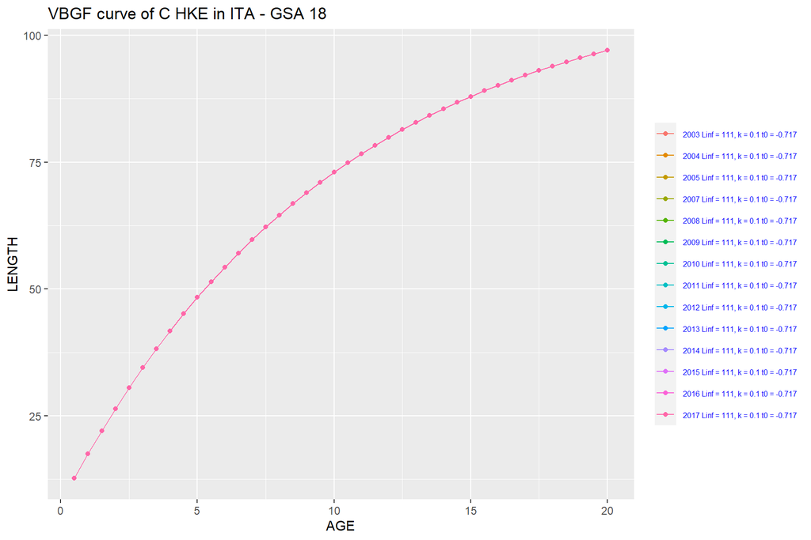

Plot of the VBGF parameter for HKE - ITA - GSA 18 - F

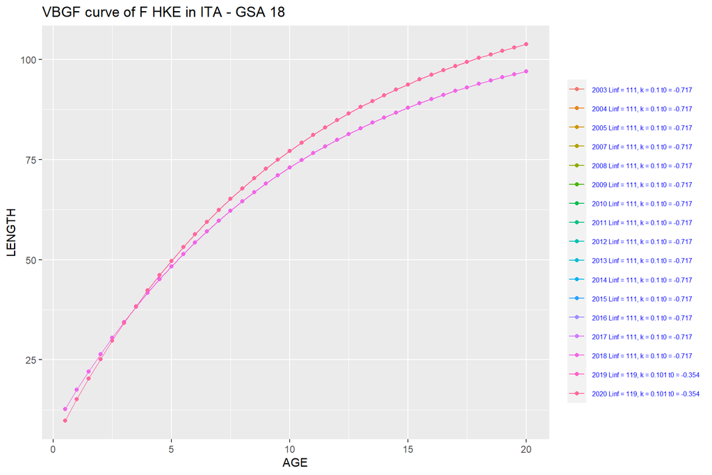

Plot of the VBGF parameter for HKE - ITA - GSA 18 - M

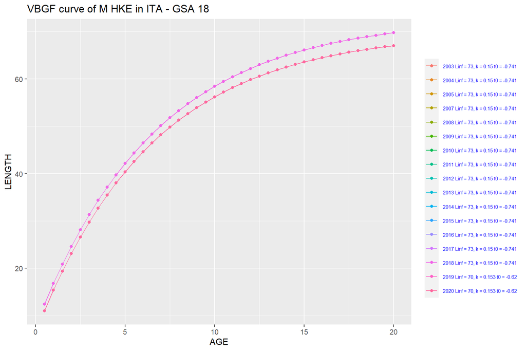

### 3.1.2 GSA 19

#### 3.1.2.1 HKE

*Summary table of VBGF parameters for HKE in GSA 19*

| COUNTRY | YEAR | START_YEAR | END_YEAR | SPECIES | SEX | COUNT |
| --- | --- | --- | --- | --- | --- | --- |
| ITA | GSA 19 | 2002 | 2003 | HKE | F | 1 |
| ITA | GSA 19 | 2004 | 2004 | HKE | F | 1 |
| ITA | GSA 19 | 2005 | 2005 | HKE | F | 1 |
| ITA | GSA 19 | 2006 | 2006 | HKE | F | 1 |
| ITA | GSA 19 | 2007 | 2007 | HKE | F | 1 |
| ITA | GSA 19 | 2008 | 2008 | HKE | F | 1 |
| ITA | GSA 19 | 2009 | 2009 | HKE | F | 1 |
| ITA | GSA 19 | 2010 | 2010 | HKE | F | 1 |
| ITA | GSA 19 | 2011 | 2011 | HKE | F | 1 |
| ITA | GSA 19 | 2012 | 2012 | HKE | F | 1 |
| ITA | GSA 19 | 2013 | 2013 | HKE | F | 1 |
| ITA | GSA 19 | 2014 | 2014 | HKE | F | 1 |
| ITA | GSA 19 | 2015 | 2015 | HKE | F | 1 |
| ITA | GSA 19 | 2016 | 2016 | HKE | F | 1 |
| ITA | GSA 19 | 2017 | 2017 | HKE | F | 1 |
| ITA | GSA 19 | 2018 | 2018 | HKE | F | 1 |
| ITA | GSA 19 | 2019 | 2019 | HKE | F | 1 |
| ITA | GSA 19 | 2020 | 2020 | HKE | F | 1 |
| ITA | GSA 19 | 2002 | 2003 | HKE | M | 1 |
| ITA | GSA 19 | 2004 | 2004 | HKE | M | 1 |
| ITA | GSA 19 | 2005 | 2005 | HKE | M | 1 |
| ITA | GSA 19 | 2006 | 2006 | HKE | M | 1 |
| ITA | GSA 19 | 2007 | 2007 | HKE | M | 1 |
| ITA | GSA 19 | 2008 | 2008 | HKE | M | 1 |
| ITA | GSA 19 | 2009 | 2009 | HKE | M | 1 |
| ITA | GSA 19 | 2010 | 2010 | HKE | M | 1 |
| ITA | GSA 19 | 2011 | 2011 | HKE | M | 1 |
| ITA | GSA 19 | 2012 | 2012 | HKE | M | 1 |
| ITA | GSA 19 | 2013 | 2013 | HKE | M | 1 |
| ITA | GSA 19 | 2014 | 2014 | HKE | M | 1 |
| ITA | GSA 19 | 2015 | 2015 | HKE | M | 1 |
| ITA | GSA 19 | 2016 | 2016 | HKE | M | 1 |
| ITA | GSA 19 | 2017 | 2017 | HKE | M | 1 |
| ITA | GSA 19 | 2018 | 2018 | HKE | M | 1 |
| ITA | GSA 19 | 2019 | 2019 | HKE | M | 1 |
| ITA | GSA 19 | 2020 | 2020 | HKE | M | 1 |

Plot of the VBGF parameter for HKE - ITA - GSA 19 - F

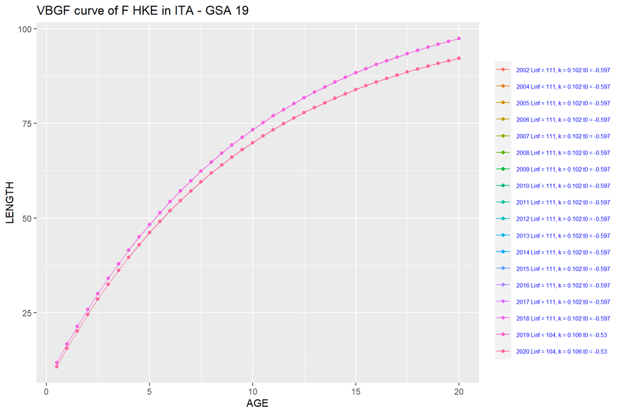

Plot of the VBGF parameter for HKE - ITA - GSA 19 - M

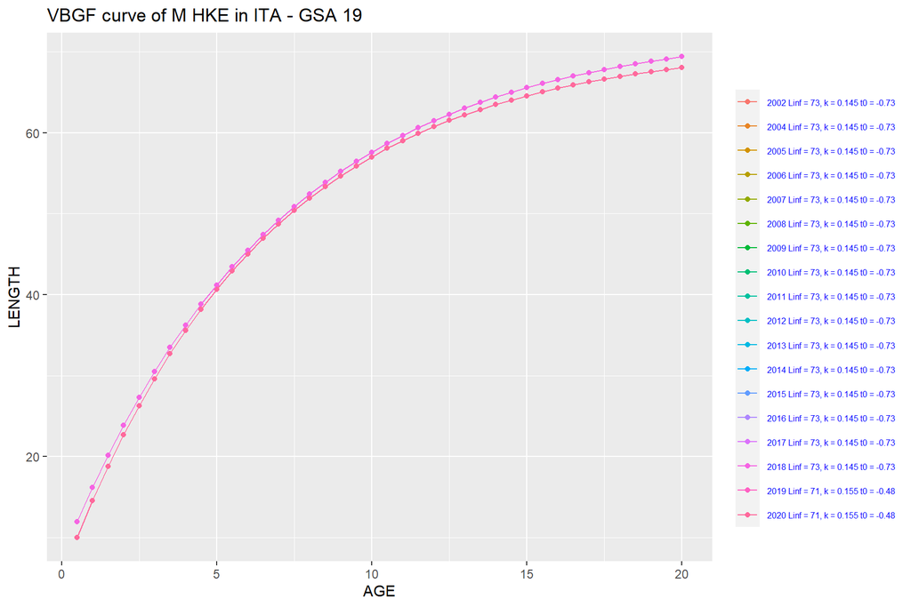

## 3.2 Plots of length-weight (LW) functions

### 3.2.1 GSA 18

#### 3.2.1.1 HKE

*Summary table of length-weight parameters for HKE in GSA 18*

| COUNTRY | AREA | START_YEAR | END_YEAR | SPECIES | SEX | NA |
| --- | --- | --- | --- | --- | --- | --- |
| ITA | GSA 18 | 2003 | 2003 | HKE | C | 1 |
| ITA | GSA 18 | 2004 | 2004 | HKE | C | 1 |
| ITA | GSA 18 | 2005 | 2005 | HKE | C | 1 |
| ITA | GSA 18 | 2007 | 2007 | HKE | C | 1 |
| ITA | GSA 18 | 2008 | 2008 | HKE | C | 1 |
| ITA | GSA 18 | 2009 | 2009 | HKE | C | 1 |
| ITA | GSA 18 | 2010 | 2010 | HKE | C | 1 |
| ITA | GSA 18 | 2011 | 2011 | HKE | C | 1 |
| ITA | GSA 18 | 2012 | 2012 | HKE | C | 1 |
| ITA | GSA 18 | 2013 | 2013 | HKE | C | 1 |
| ITA | GSA 18 | 2014 | 2014 | HKE | C | 1 |
| ITA | GSA 18 | 2015 | 2015 | HKE | C | 1 |
| ITA | GSA 18 | 2016 | 2016 | HKE | C | 1 |
| ITA | GSA 18 | 2017 | 2017 | HKE | C | 1 |
| ITA | GSA 18 | 2003 | 2003 | HKE | F | 1 |
| ITA | GSA 18 | 2004 | 2004 | HKE | F | 1 |
| ITA | GSA 18 | 2005 | 2005 | HKE | F | 1 |
| ITA | GSA 18 | 2007 | 2007 | HKE | F | 1 |
| ITA | GSA 18 | 2008 | 2008 | HKE | F | 1 |
| ITA | GSA 18 | 2009 | 2009 | HKE | F | 1 |
| ITA | GSA 18 | 2010 | 2010 | HKE | F | 1 |
| ITA | GSA 18 | 2011 | 2011 | HKE | F | 1 |
| ITA | GSA 18 | 2012 | 2012 | HKE | F | 1 |
| ITA | GSA 18 | 2013 | 2013 | HKE | F | 1 |
| ITA | GSA 18 | 2014 | 2014 | HKE | F | 1 |
| ITA | GSA 18 | 2015 | 2015 | HKE | F | 1 |
| ITA | GSA 18 | 2016 | 2016 | HKE | F | 1 |
| ITA | GSA 18 | 2017 | 2017 | HKE | F | 1 |
| ITA | GSA 18 | 2018 | 2018 | HKE | F | 1 |
| ITA | GSA 18 | 2019 | 2019 | HKE | F | 1 |
| ITA | GSA 18 | 2020 | 2020 | HKE | F | 1 |
| ITA | GSA 18 | 2003 | 2003 | HKE | M | 1 |
| ITA | GSA 18 | 2004 | 2004 | HKE | M | 1 |
| ITA | GSA 18 | 2005 | 2005 | HKE | M | 1 |
| ITA | GSA 18 | 2007 | 2007 | HKE | M | 1 |
| ITA | GSA 18 | 2008 | 2008 | HKE | M | 1 |
| ITA | GSA 18 | 2009 | 2009 | HKE | M | 1 |
| ITA | GSA 18 | 2010 | 2010 | HKE | M | 1 |
| ITA | GSA 18 | 2011 | 2011 | HKE | M | 1 |
| ITA | GSA 18 | 2012 | 2012 | HKE | M | 1 |
| ITA | GSA 18 | 2013 | 2013 | HKE | M | 1 |
| ITA | GSA 18 | 2014 | 2014 | HKE | M | 1 |
| ITA | GSA 18 | 2015 | 2015 | HKE | M | 1 |
| ITA | GSA 18 | 2016 | 2016 | HKE | M | 1 |
| ITA | GSA 18 | 2017 | 2017 | HKE | M | 1 |
| ITA | GSA 18 | 2018 | 2018 | HKE | M | 1 |
| ITA | GSA 18 | 2019 | 2019 | HKE | M | 1 |
| ITA | GSA 18 | 2020 | 2020 | HKE | M | 1 |

Plot of the length-weight parameters for HKE - ITA - GSA 18 - C

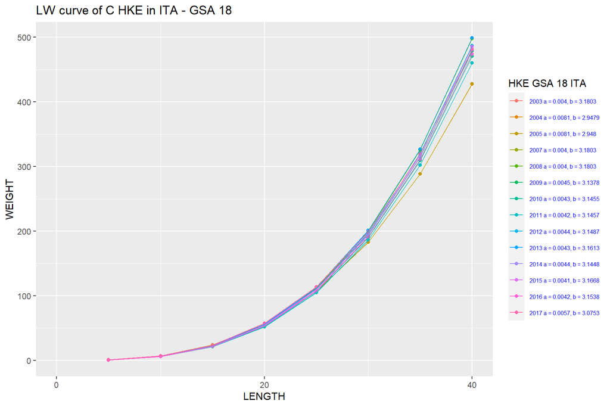

Plot of the length-weight parameters for HKE - ITA - GSA 18 - F

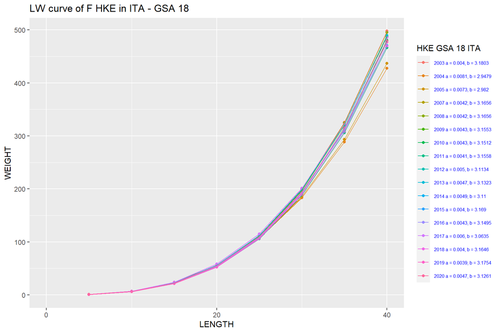

Plot of the length-weight parameters for HKE - ITA - GSA 18 - M

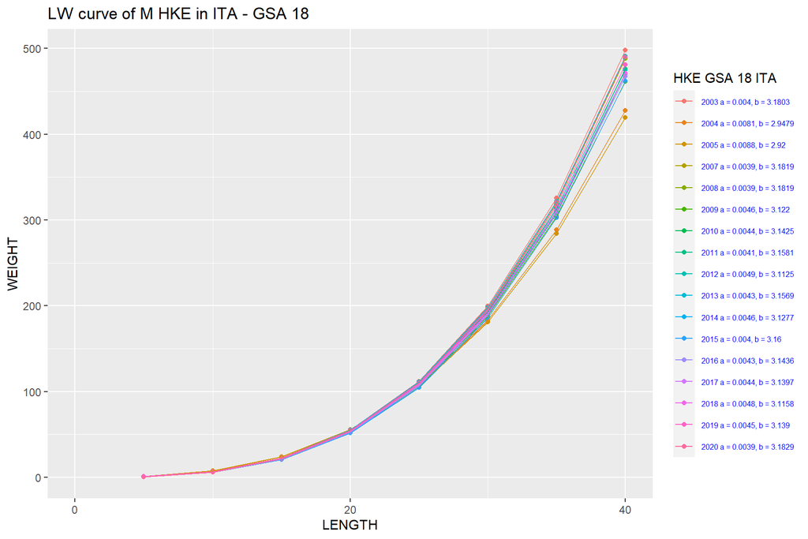

### 3.2.2 GSA 19

#### 3.2.2.1 HKE

*Summary table of length-weight parameters for HKE in GSA 19*

| COUNTRY | AREA | START_YEAR | END_YEAR | SPECIES | SEX | NA |
| --- | --- | --- | --- | --- | --- | --- |
| ITA | GSA 19 | 2002 | 2003 | HKE | F | 1 |
| ITA | GSA 19 | 2004 | 2004 | HKE | F | 1 |
| ITA | GSA 19 | 2005 | 2005 | HKE | F | 1 |
| ITA | GSA 19 | 2006 | 2006 | HKE | F | 1 |
| ITA | GSA 19 | 2007 | 2007 | HKE | F | 1 |
| ITA | GSA 19 | 2008 | 2008 | HKE | F | 1 |
| ITA | GSA 19 | 2009 | 2009 | HKE | F | 1 |
| ITA | GSA 19 | 2010 | 2010 | HKE | F | 1 |
| ITA | GSA 19 | 2011 | 2011 | HKE | F | 1 |
| ITA | GSA 19 | 2012 | 2012 | HKE | F | 1 |
| ITA | GSA 19 | 2013 | 2013 | HKE | F | 1 |
| ITA | GSA 19 | 2014 | 2014 | HKE | F | 1 |
| ITA | GSA 19 | 2015 | 2015 | HKE | F | 1 |
| ITA | GSA 19 | 2016 | 2016 | HKE | F | 1 |
| ITA | GSA 19 | 2017 | 2017 | HKE | F | 1 |
| ITA | GSA 19 | 2018 | 2018 | HKE | F | 1 |
| ITA | GSA 19 | 2019 | 2019 | HKE | F | 1 |
| ITA | GSA 19 | 2020 | 2020 | HKE | F | 1 |
| ITA | GSA 19 | 2002 | 2003 | HKE | M | 1 |
| ITA | GSA 19 | 2004 | 2004 | HKE | M | 1 |
| ITA | GSA 19 | 2005 | 2005 | HKE | M | 1 |
| ITA | GSA 19 | 2006 | 2006 | HKE | M | 1 |
| ITA | GSA 19 | 2007 | 2007 | HKE | M | 1 |
| ITA | GSA 19 | 2008 | 2008 | HKE | M | 1 |
| ITA | GSA 19 | 2009 | 2009 | HKE | M | 1 |
| ITA | GSA 19 | 2010 | 2010 | HKE | M | 1 |
| ITA | GSA 19 | 2011 | 2011 | HKE | M | 1 |
| ITA | GSA 19 | 2012 | 2012 | HKE | M | 1 |
| ITA | GSA 19 | 2013 | 2013 | HKE | M | 1 |
| ITA | GSA 19 | 2014 | 2014 | HKE | M | 1 |
| ITA | GSA 19 | 2015 | 2015 | HKE | M | 1 |
| ITA | GSA 19 | 2016 | 2016 | HKE | M | 1 |
| ITA | GSA 19 | 2017 | 2017 | HKE | M | 1 |
| ITA | GSA 19 | 2018 | 2018 | HKE | M | 1 |
| ITA | GSA 19 | 2019 | 2019 | HKE | M | 1 |
| ITA | GSA 19 | 2020 | 2020 | HKE | M | 1 |

Plot of the length-weight parameters for HKE - ITA - GSA 19 - F

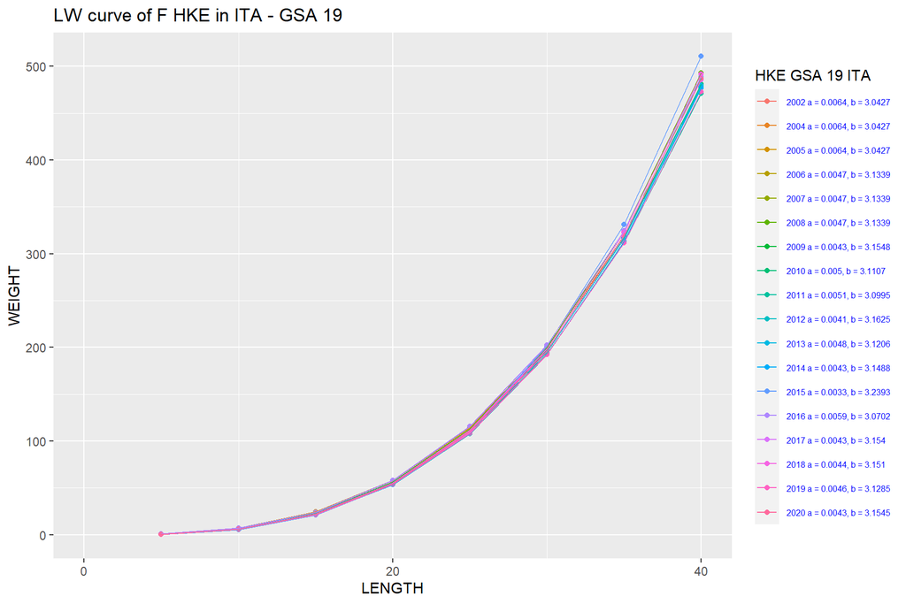

Plot of the length-weight parameters for HKE - ITA - GSA 19 - M

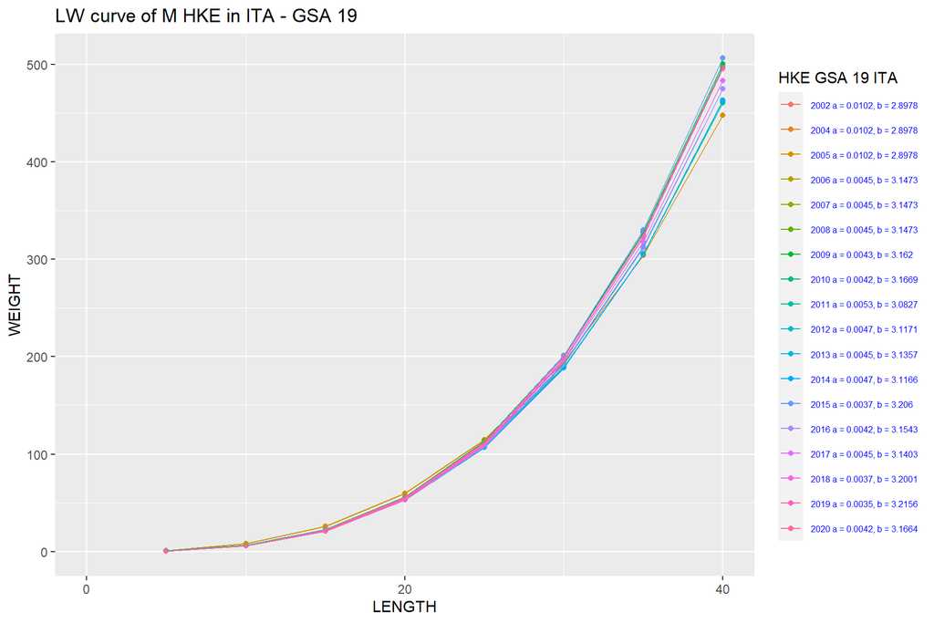

## 3.3 Plots of Maturity at Age (MA) data

### 3.3.1 GSA 18

#### 3.3.1.1 HKE

*Summary table of percentage of matures at age for HKE in GSA 18*

| COUNTRY | YEAR | START_YEAR | END_YEAR | SPECIES | SEX | COUNT |
| --- | --- | --- | --- | --- | --- | --- |
| ITA | GSA 18 | 2002 | 2002 | HKE | F | 9 |
| ITA | GSA 18 | 2003 | 2005 | HKE | F | 6 |
| ITA | GSA 18 | 2006 | 2008 | HKE | F | 14 |
| ITA | GSA 18 | 2009 | 2009 | HKE | F | 15 |
| ITA | GSA 18 | 2010 | 2010 | HKE | F | 16 |
| ITA | GSA 18 | 2011 | 2011 | HKE | F | 15 |
| ITA | GSA 18 | 2012 | 2012 | HKE | F | 14 |
| ITA | GSA 18 | 2013 | 2013 | HKE | F | 13 |
| ITA | GSA 18 | 2014 | 2014 | HKE | F | 15 |
| ITA | GSA 18 | 2015 | 2015 | HKE | F | 13 |
| ITA | GSA 18 | 2016 | 2016 | HKE | F | 15 |
| ITA | GSA 18 | 2017 | 2017 | HKE | F | 18 |
| ITA | GSA 18 | 2018 | 2018 | HKE | F | 15 |
| ITA | GSA 18 | 2019 | 2019 | HKE | F | 13 |
| ITA | GSA 18 | 2020 | 2020 | HKE | F | 12 |
| ITA | GSA 18 | 2002 | 2002 | HKE | M | 5 |
| ITA | GSA 18 | 2003 | 2005 | HKE | M | 4 |
| ITA | GSA 18 | 2006 | 2008 | HKE | M | 12 |
| ITA | GSA 18 | 2009 | 2009 | HKE | M | 12 |
| ITA | GSA 18 | 2010 | 2010 | HKE | M | 11 |
| ITA | GSA 18 | 2011 | 2011 | HKE | M | 12 |
| ITA | GSA 18 | 2012 | 2012 | HKE | M | 10 |
| ITA | GSA 18 | 2013 | 2013 | HKE | M | 7 |
| ITA | GSA 18 | 2014 | 2014 | HKE | M | 9 |
| ITA | GSA 18 | 2015 | 2015 | HKE | M | 10 |
| ITA | GSA 18 | 2016 | 2016 | HKE | M | 10 |
| ITA | GSA 18 | 2017 | 2017 | HKE | M | 7 |
| ITA | GSA 18 | 2018 | 2018 | HKE | M | 7 |
| ITA | GSA 18 | 2019 | 2019 | HKE | M | 9 |
| ITA | GSA 18 | 2020 | 2020 | HKE | M | 8 |

Plot of the percercentage of matures at age for HKE - ITA - GSA 18 - M

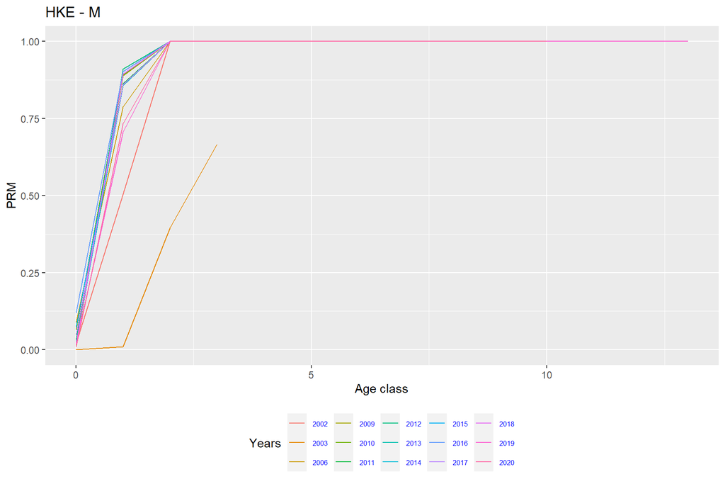

Plot of the percercentage of matures at age for HKE - ITA - GSA 18 - F

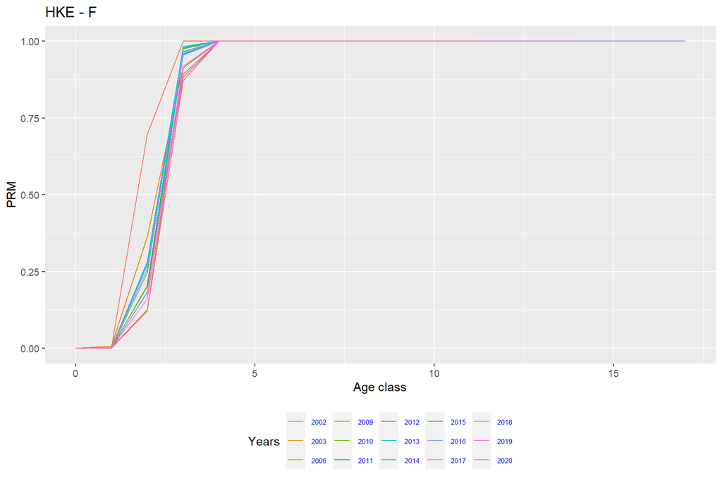

### 3.3.2 GSA 19

#### 3.3.2.1 HKE

*Summary table of percentage of matures at age for HKE in GSA 19*

| COUNTRY | YEAR | START_YEAR | END_YEAR | SPECIES | SEX | COUNT |
| --- | --- | --- | --- | --- | --- | --- |
| ITA | GSA 19 | 2002 | 2002 | HKE | F | 9 |
| ITA | GSA 19 | 2003 | 2005 | HKE | F | 7 |
| ITA | GSA 19 | 2006 | 2008 | HKE | F | 12 |
| ITA | GSA 19 | 2009 | 2009 | HKE | F | 10 |
| ITA | GSA 19 | 2010 | 2010 | HKE | F | 11 |
| ITA | GSA 19 | 2011 | 2011 | HKE | F | 10 |
| ITA | GSA 19 | 2012 | 2012 | HKE | F | 8 |
| ITA | GSA 19 | 2013 | 2013 | HKE | F | 9 |
| ITA | GSA 19 | 2014 | 2014 | HKE | F | 13 |
| ITA | GSA 19 | 2015 | 2015 | HKE | F | 10 |
| ITA | GSA 19 | 2016 | 2016 | HKE | F | 10 |
| ITA | GSA 19 | 2017 | 2017 | HKE | F | 9 |
| ITA | GSA 19 | 2018 | 2018 | HKE | F | 8 |
| ITA | GSA 19 | 2019 | 2019 | HKE | F | 15 |
| ITA | GSA 19 | 2020 | 2020 | HKE | F | 9 |
| ITA | GSA 19 | 2002 | 2002 | HKE | M | 8 |
| ITA | GSA 19 | 2003 | 2005 | HKE | M | 6 |
| ITA | GSA 19 | 2006 | 2008 | HKE | M | 10 |
| ITA | GSA 19 | 2009 | 2009 | HKE | M | 7 |
| ITA | GSA 19 | 2010 | 2010 | HKE | M | 8 |
| ITA | GSA 19 | 2011 | 2011 | HKE | M | 8 |
| ITA | GSA 19 | 2012 | 2012 | HKE | M | 9 |
| ITA | GSA 19 | 2013 | 2013 | HKE | M | 7 |
| ITA | GSA 19 | 2014 | 2014 | HKE | M | 6 |
| ITA | GSA 19 | 2015 | 2015 | HKE | M | 6 |
| ITA | GSA 19 | 2016 | 2016 | HKE | M | 6 |
| ITA | GSA 19 | 2017 | 2017 | HKE | M | 5 |
| ITA | GSA 19 | 2018 | 2018 | HKE | M | 5 |
| ITA | GSA 19 | 2019 | 2019 | HKE | M | 11 |
| ITA | GSA 19 | 2020 | 2020 | HKE | M | 7 |

Plot of the percercentage of matures at age for HKE - ITA - GSA 19 - F

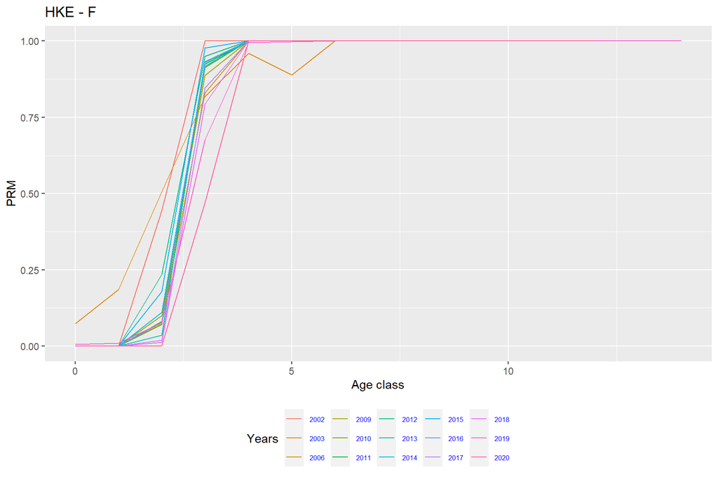

Plot of the percercentage of matures at age for HKE - ITA - GSA 19 - M

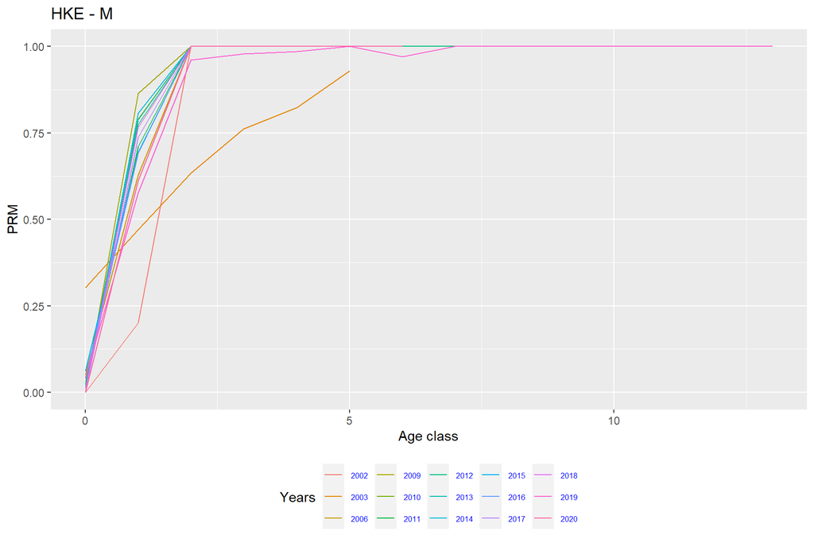

## 3.4 Plots of Maturity at Length (ML) data

### 3.4.1 GSA 18

#### 3.4.1.1 HKE

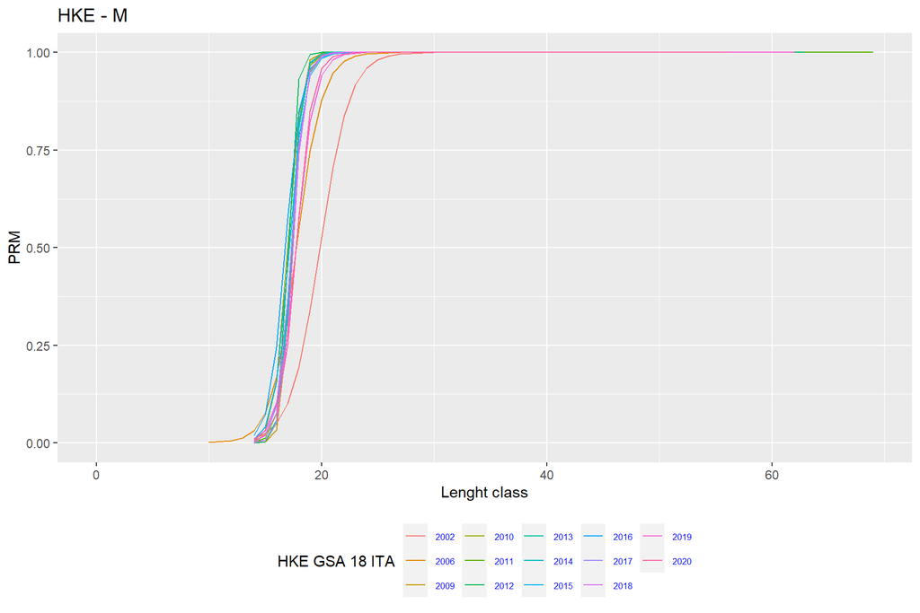

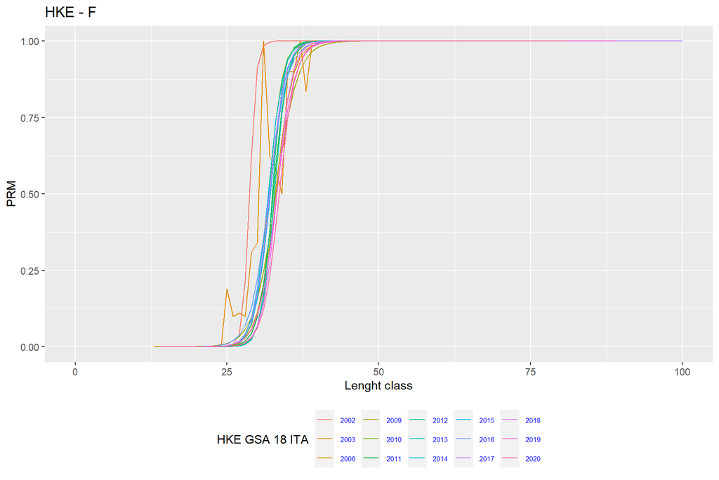

*Summary table of percentage of matures at length for HKE in GSA 18*

| COUNTRY | YEAR | START_YEAR | END_YEAR | SPECIES | SEX | COUNT |
| --- | --- | --- | --- | --- | --- | --- |
| ITA | GSA 18 | 2002 | 2002 | HKE | F | 45 |
| ITA | GSA 18 | 2003 | 2005 | HKE | F | 34 |
| ITA | GSA 18 | 2006 | 2008 | HKE | F | 68 |
| ITA | GSA 18 | 2009 | 2009 | HKE | F | 68 |
| ITA | GSA 18 | 2010 | 2010 | HKE | F | 71 |
| ITA | GSA 18 | 2011 | 2011 | HKE | F | 70 |
| ITA | GSA 18 | 2012 | 2012 | HKE | F | 69 |
| ITA | GSA 18 | 2013 | 2013 | HKE | F | 66 |
| ITA | GSA 18 | 2014 | 2014 | HKE | F | 70 |
| ITA | GSA 18 | 2015 | 2015 | HKE | F | 66 |
| ITA | GSA 18 | 2016 | 2016 | HKE | F | 66 |
| ITA | GSA 18 | 2017 | 2017 | HKE | F | 69 |
| ITA | GSA 18 | 2018 | 2018 | HKE | F | 71 |
| ITA | GSA 18 | 2019 | 2019 | HKE | F | 65 |
| ITA | GSA 18 | 2020 | 2020 | HKE | F | 68 |
| ITA | GSA 18 | 2002 | 2002 | HKE | M | 25 |
| ITA | GSA 18 | 2006 | 2008 | HKE | M | 48 |
| ITA | GSA 18 | 2009 | 2009 | HKE | M | 41 |
| ITA | GSA 18 | 2010 | 2010 | HKE | M | 40 |
| ITA | GSA 18 | 2011 | 2011 | HKE | M | 45 |
| ITA | GSA 18 | 2012 | 2012 | HKE | M | 36 |
| ITA | GSA 18 | 2013 | 2013 | HKE | M | 31 |
| ITA | GSA 18 | 2014 | 2014 | HKE | M | 35 |
| ITA | GSA 18 | 2015 | 2015 | HKE | M | 36 |
| ITA | GSA 18 | 2016 | 2016 | HKE | M | 32 |
| ITA | GSA 18 | 2017 | 2017 | HKE | M | 33 |
| ITA | GSA 18 | 2018 | 2018 | HKE | M | 33 |
| ITA | GSA 18 | 2019 | 2019 | HKE | M | 31 |
| ITA | GSA 18 | 2020 | 2020 | HKE | M | 33 |

### 3.4.2 GSA 19

#### 3.4.2.1 HKE

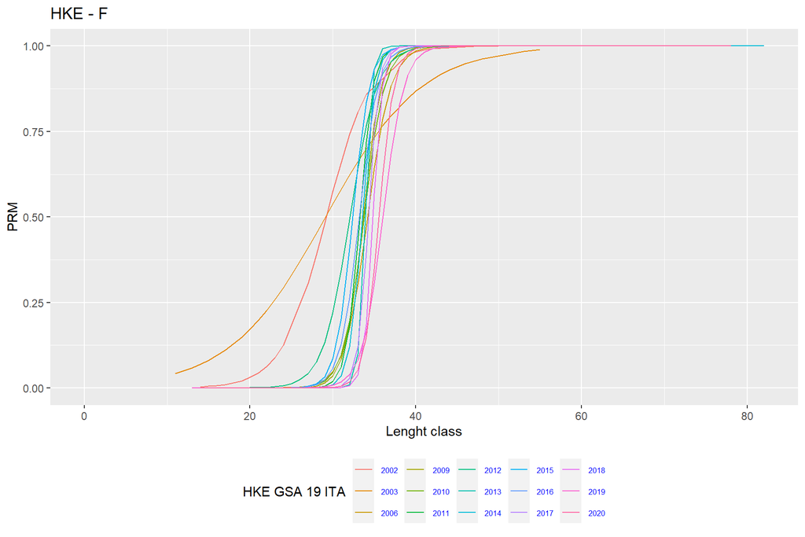

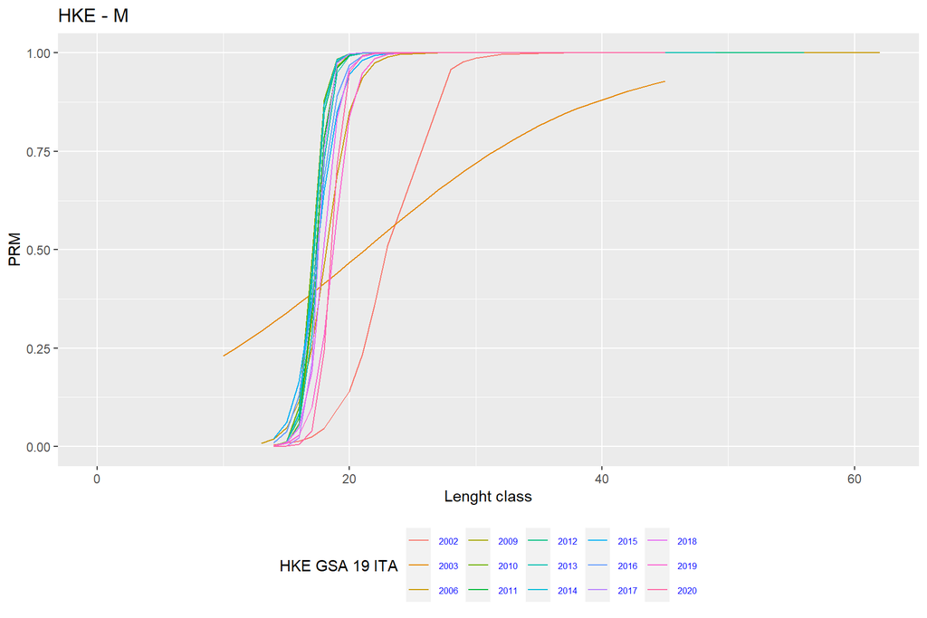

*Summary table of percentage of matures at length for HKE in GSA 19*

| COUNTRY | YEAR | START_YEAR | END_YEAR | SPECIES | SEX | COUNT |
| --- | --- | --- | --- | --- | --- | --- |
| ITA | GSA 19 | 2002 | 2002 | HKE | F | 34 |
| ITA | GSA 19 | 2003 | 2005 | HKE | F | 36 |
| ITA | GSA 19 | 2006 | 2008 | HKE | F | 65 |
| ITA | GSA 19 | 2009 | 2009 | HKE | F | 53 |
| ITA | GSA 19 | 2010 | 2010 | HKE | F | 53 |
| ITA | GSA 19 | 2011 | 2011 | HKE | F | 55 |
| ITA | GSA 19 | 2012 | 2012 | HKE | F | 47 |
| ITA | GSA 19 | 2013 | 2013 | HKE | F | 49 |
| ITA | GSA 19 | 2014 | 2014 | HKE | F | 55 |
| ITA | GSA 19 | 2015 | 2015 | HKE | F | 50 |
| ITA | GSA 19 | 2016 | 2016 | HKE | F | 49 |
| ITA | GSA 19 | 2017 | 2017 | HKE | F | 41 |
| ITA | GSA 19 | 2018 | 2018 | HKE | F | 48 |
| ITA | GSA 19 | 2019 | 2019 | HKE | F | 51 |
| ITA | GSA 19 | 2020 | 2020 | HKE | F | 44 |
| ITA | GSA 19 | 2002 | 2002 | HKE | M | 18 |
| ITA | GSA 19 | 2003 | 2005 | HKE | M | 30 |
| ITA | GSA 19 | 2006 | 2008 | HKE | M | 38 |
| ITA | GSA 19 | 2009 | 2009 | HKE | M | 33 |
| ITA | GSA 19 | 2010 | 2010 | HKE | M | 32 |
| ITA | GSA 19 | 2011 | 2011 | HKE | M | 32 |
| ITA | GSA 19 | 2012 | 2012 | HKE | M | 37 |
| ITA | GSA 19 | 2013 | 2013 | HKE | M | 32 |
| ITA | GSA 19 | 2014 | 2014 | HKE | M | 28 |
| ITA | GSA 19 | 2015 | 2015 | HKE | M | 24 |
| ITA | GSA 19 | 2016 | 2016 | HKE | M | 25 |
| ITA | GSA 19 | 2017 | 2017 | HKE | M | 22 |
| ITA | GSA 19 | 2018 | 2018 | HKE | M | 27 |
| ITA | GSA 19 | 2019 | 2019 | HKE | M | 26 |
| ITA | GSA 19 | 2020 | 2020 | HKE | M | 29 |

## 3.5 Plots of Sex Ratio at age (SRA) data

### 3.5.1 GSA 18

#### 3.5.1.1 HKE

*Summary table of sex ratio at age for HKE in GSA 18*

| COUNTRY | YEAR | START_YEAR | END_YEAR | SPECIES |
| --- | --- | --- | --- | --- |
| ITA | GSA 18 | 2002 | 2002 | HKE |
| ITA | GSA 18 | 2003 | 2005 | HKE |
| ITA | GSA 18 | 2006 | 2008 | HKE |
| ITA | GSA 18 | 2017 | 2017 | HKE |
| ITA | GSA 18 | 2018 | 2018 | HKE |
| ITA | GSA 18 | 2019 | 2019 | HKE |
| ITA | GSA 18 | 2020 | 2020 | HKE |

Plot of sex ratio at age for HKE - ITA - GSA 18 - M

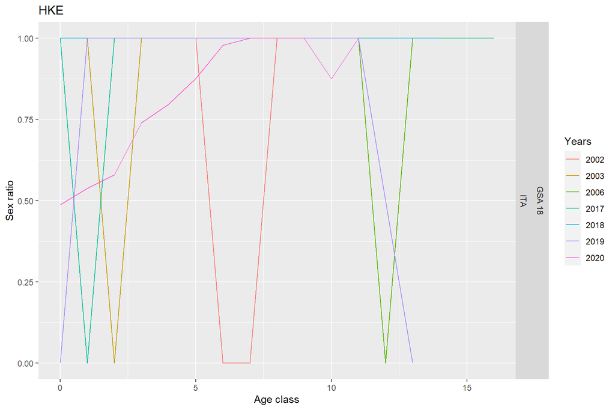

### 3.5.2 GSA 19

#### 3.5.2.1 HKE

*Summary table of sex ratio at age for HKE in GSA 19*

| COUNTRY | YEAR | START_YEAR | END_YEAR | SPECIES |
| --- | --- | --- | --- | --- |
| ITA | GSA 19 | 2002 | 2002 | HKE |
| ITA | GSA 19 | 2003 | 2005 | HKE |
| ITA | GSA 19 | 2006 | 2008 | HKE |
| ITA | GSA 19 | 2009 | 2009 | HKE |
| ITA | GSA 19 | 2010 | 2010 | HKE |
| ITA | GSA 19 | 2011 | 2011 | HKE |
| ITA | GSA 19 | 2012 | 2012 | HKE |
| ITA | GSA 19 | 2013 | 2013 | HKE |
| ITA | GSA 19 | 2014 | 2014 | HKE |
| ITA | GSA 19 | 2015 | 2015 | HKE |
| ITA | GSA 19 | 2016 | 2016 | HKE |
| ITA | GSA 19 | 2017 | 2017 | HKE |
| ITA | GSA 19 | 2018 | 2018 | HKE |
| ITA | GSA 19 | 2019 | 2019 | HKE |
| ITA | GSA 19 | 2020 | 2020 | HKE |

Plot of sex ratio at age for HKE - ITA - GSA 19 - M

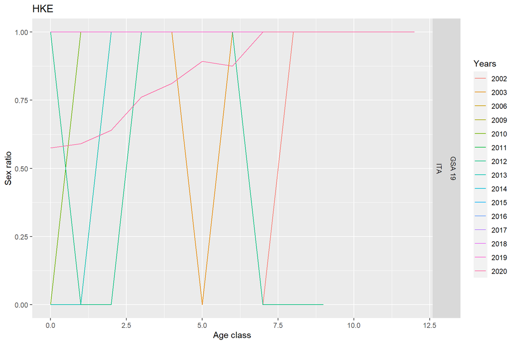

## 3.6 Plots of Sex Ratio at length (SRL) data

### 3.6.1 GSA 18

#### 3.6.1.1 HKE

*Summary table of sex ratio at length for HKE in GSA 18*

| COUNTRY | GSA | START_YEAR | END_YEAR | SPECIES | COUNT |
| --- | --- | --- | --- | --- | --- |
| ITA | GSA 18 | 2002 | 2002 | HKE | 45 |
| ITA | GSA 18 | 2003 | 2005 | HKE | 34 |
| ITA | GSA 18 | 2006 | 2008 | HKE | 70 |
| ITA | GSA 18 | 2009 | 2009 | HKE | 68 |
| ITA | GSA 18 | 2010 | 2010 | HKE | 71 |
| ITA | GSA 18 | 2011 | 2011 | HKE | 70 |
| ITA | GSA 18 | 2012 | 2012 | HKE | 69 |
| ITA | GSA 18 | 2013 | 2013 | HKE | 66 |
| ITA | GSA 18 | 2014 | 2014 | HKE | 70 |
| ITA | GSA 18 | 2015 | 2015 | HKE | 66 |
| ITA | GSA 18 | 2016 | 2016 | HKE | 66 |
| ITA | GSA 18 | 2017 | 2017 | HKE | 69 |
| ITA | GSA 18 | 2018 | 2018 | HKE | 71 |
| ITA | GSA 18 | 2019 | 2019 | HKE | 65 |
| ITA | GSA 18 | 2020 | 2020 | HKE | 68 |

Plot of sex ratio at length for HKE - ITA - GSA 18 - M

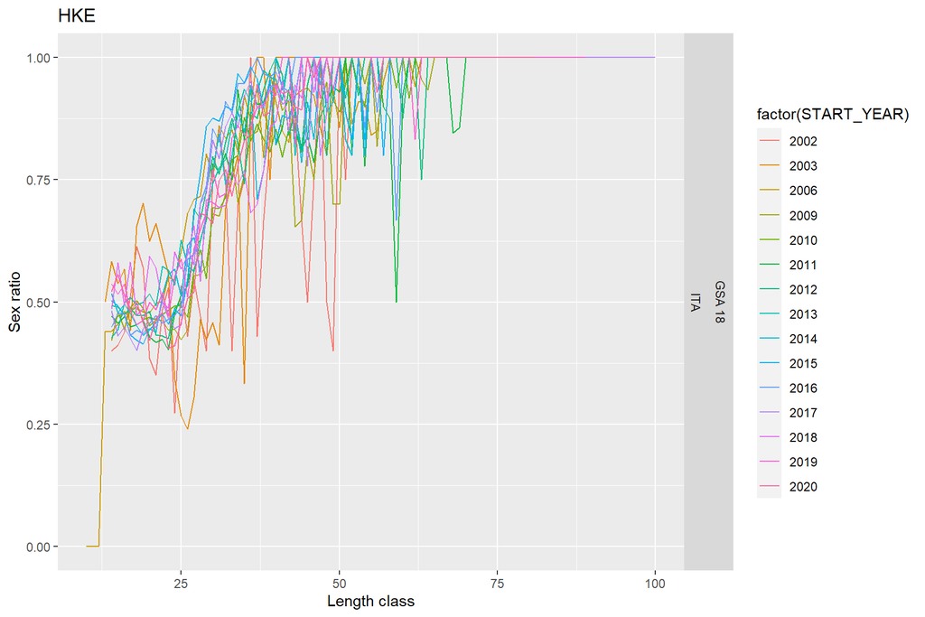

### 3.6.2 GSA 19

#### 3.6.2.1 HKE

*Summary table of sex ratio at length for HKE in GSA 19*

| COUNTRY | GSA | START_YEAR | END_YEAR | SPECIES | COUNT |
| --- | --- | --- | --- | --- | --- |
| ITA | GSA 19 | 2002 | 2002 | HKE | 43 |
| ITA | GSA 19 | 2003 | 2005 | HKE | 39 |
| ITA | GSA 19 | 2006 | 2008 | HKE | 68 |
| ITA | GSA 19 | 2009 | 2009 | HKE | 53 |
| ITA | GSA 19 | 2010 | 2010 | HKE | 53 |
| ITA | GSA 19 | 2011 | 2011 | HKE | 55 |
| ITA | GSA 19 | 2012 | 2012 | HKE | 47 |
| ITA | GSA 19 | 2013 | 2013 | HKE | 49 |
| ITA | GSA 19 | 2014 | 2014 | HKE | 55 |
| ITA | GSA 19 | 2015 | 2015 | HKE | 50 |
| ITA | GSA 19 | 2016 | 2016 | HKE | 49 |
| ITA | GSA 19 | 2017 | 2017 | HKE | 41 |
| ITA | GSA 19 | 2018 | 2018 | HKE | 48 |
| ITA | GSA 19 | 2019 | 2019 | HKE | 51 |
| ITA | GSA 19 | 2020 | 2020 | HKE | 44 |

Plot of sex ratio at length for HKE - ITA - GSA 19 - M

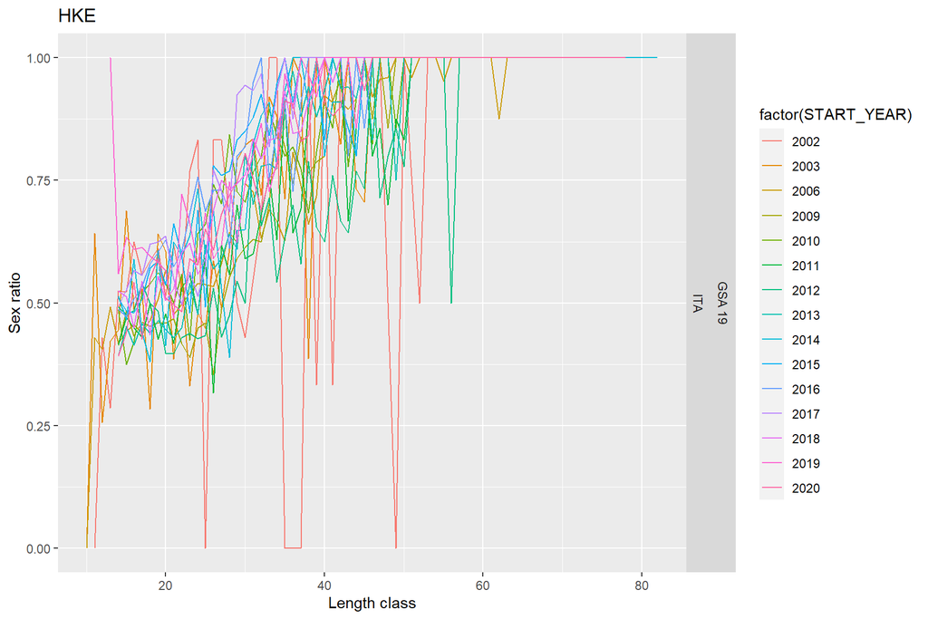

## 3.7 Plots of Age-Length Keys (ALK) data

### 3.7.1 GSA 18

#### 3.7.1.1 HKE

Plot of ALK for HKE - ITA - GSA 18 - Females

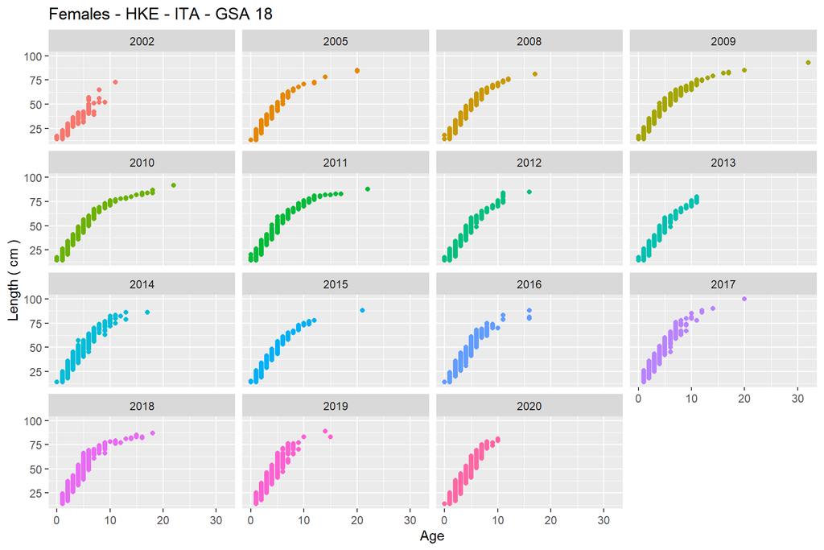

Plot of ALK for HKE - ITA - GSA 18 - Males

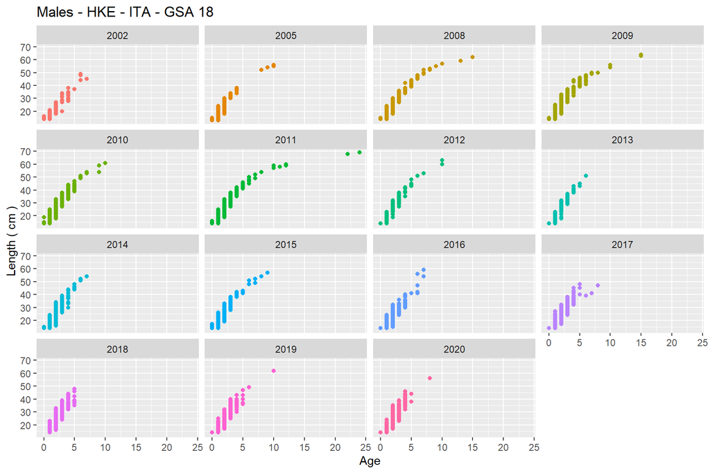

Plot of ALK for HKE - ITA - GSA 18 - Combined

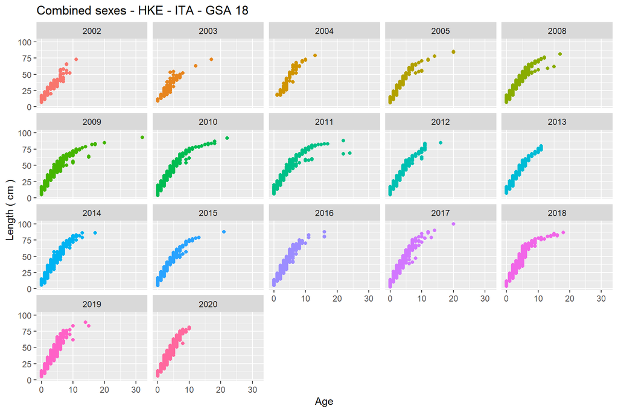

### 3.7.2 GSA 19

#### 3.7.2.1 HKE

Plot of ALK for HKE - ITA - GSA 19 - Females

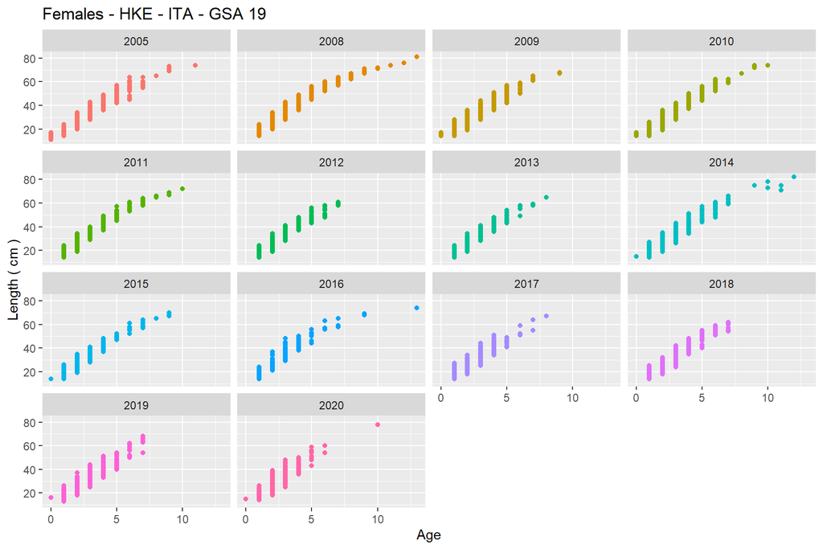

Plot of ALK for HKE - ITA - GSA 19 - Males

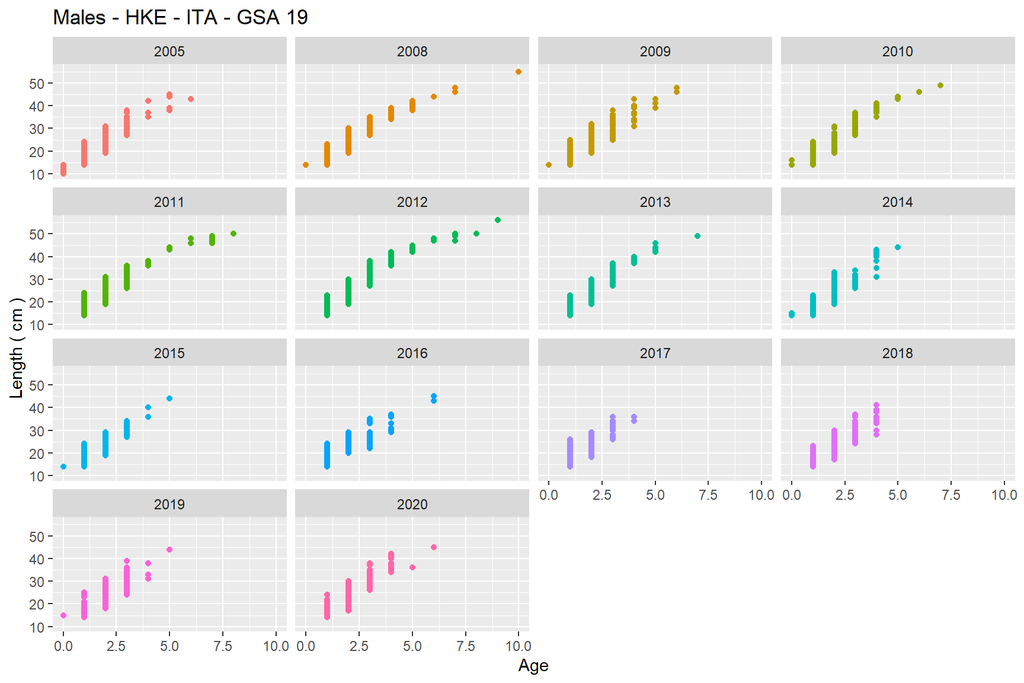

Plot of ALK for HKE - ITA - GSA 19 - Combined

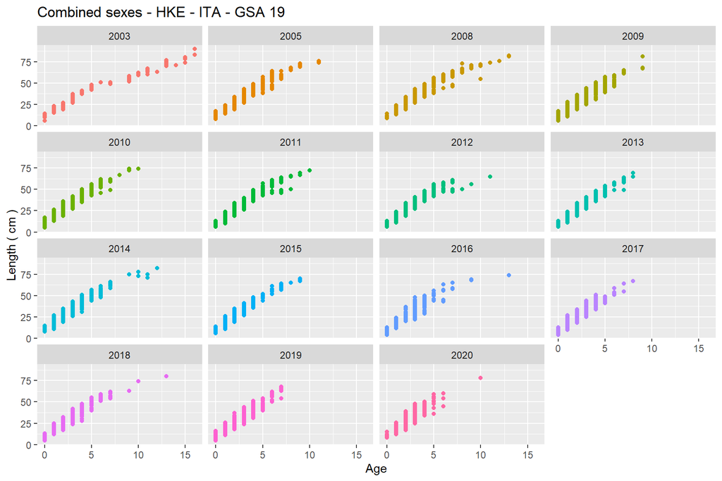